# Part I - (Exploration of Loan Data from prosper)

## Introduction

> This project exploreS dataset containing 113,937 loans with 81 variables on each loan, including loan amount, borrower rate (or interest rate), current loan status, borrower income, and many others.

## Preliminary Wrangling

```python
# import all packages and set plots to be embedded inline
import numpy as np
import pandas as pd
import matplotlib.pyplot as plt
import seaborn as sb

%matplotlib inline
```

```python
# lets load our dataset and assess

df_loan = pd.read_csv('prosperLoanData.csv')
df_loan.head()
```

|  | ListingKey | ListingNumber | ListingCreationDate | CreditGrade | Term | LoanStatus | ClosedDate | BorrowerAPR | BorrowerRate | LenderYield | ... | LP_ServiceFees | LP_CollectionFees | LP_GrossPrincipalLoss | LP_NetPrincipalLoss | LP_NonPrincipalRecoverypayments | PercentFunded | Recommendations | InvestmentFromFriendsCount | InvestmentFromFriendsAmount | Investors |
| --- | --- | --- | --- | --- | --- | --- | --- | --- | --- | --- | --- | --- | --- | --- | --- | --- | --- | --- | --- | --- | --- |
| 0 | 1021339766868145413AB3B | 193129 | 2007-08-26 19:09:29.263000000 | C | 36 | Completed | 2009-08-14 00:00:00 | 0.16516 | 0.1580 | 0.1380 | ... | -133.18 | 0.0 | 0.0 | 0.0 | 0.0 | 1.0 | 0 | 0 | 0.0 | 258 |
| 1 | 10273602499503308B223C1 | 1209647 | 2014-02-27 08:28:07.900000000 | NaN | 36 | Current | NaN | 0.12016 | 0.0920 | 0.0820 | ... | 0.00 | 0.0 | 0.0 | 0.0 | 0.0 | 1.0 | 0 | 0 | 0.0 | 1 |
| 2 | 0EE9337825851032864889A | 81716 | 2007-01-05 15:00:47.090000000 | HR | 36 | Completed | 2009-12-17 00:00:00 | 0.28269 | 0.2750 | 0.2400 | ... | -24.20 | 0.0 | 0.0 | 0.0 | 0.0 | 1.0 | 0 | 0 | 0.0 | 41 |
| 3 | 0EF5356002482715299901A | 658116 | 2012-10-22 11:02:35.010000000 | NaN | 36 | Current | NaN | 0.12528 | 0.0974 | 0.0874 | ... | -108.01 | 0.0 | 0.0 | 0.0 | 0.0 | 1.0 | 0 | 0 | 0.0 | 158 |
| 4 | 0F023589499656230C5E3E2 | 909464 | 2013-09-14 18:38:39.097000000 | NaN | 36 | Current | NaN | 0.24614 | 0.2085 | 0.1985 | ... | -60.27 | 0.0 | 0.0 | 0.0 | 0.0 | 1.0 | 0 | 0 | 0.0 | 20 |

5 rows × 81 columns

```python
# General assessment of the Data
df_loan.info()
```

```
<class 'pandas.core.frame.DataFrame'>
RangeIndex: 113937 entries, 0 to 113936
Data columns (total 81 columns):
 #   Column                               Non-Null Count   Dtype
---  ------                               --------------   -----
 0   ListingKey                           113937 non-null  object
 1   ListingNumber                        113937 non-null  int64
 2   ListingCreationDate                  113937 non-null  object
 3   CreditGrade                          28953 non-null   object
 4   Term                                 113937 non-null  int64
 5   LoanStatus                           113937 non-null  object
 6   ClosedDate                           55089 non-null   object
 7   BorrowerAPR                          113912 non-null  float64
 8   BorrowerRate                         113937 non-null  float64
 9   LenderYield                          113937 non-null  float64
```

[output cut: 73 more lines]

```python
print(df_loan.shape)
print(df_loan.dtypes)
print(df_loan.head(10))
```

```
(113937, 81)
ListingKey                      object
ListingNumber                    int64
ListingCreationDate             object
CreditGrade                     object
Term                             int64
                                ...
PercentFunded                  float64
Recommendations                  int64
InvestmentFromFriendsCount       int64
InvestmentFromFriendsAmount    float64
Investors                        int64
Length: 81, dtype: object
                ListingKey  ListingNumber            ListingCreationDate  \
0  1021339766868145413AB3B         193129  2007-08-26 19:09:29.263000000
```

[output cut: 71 more lines]

```python
#lets select the key features am will be exploring in the Dataset

df_loan_vis = df_loan[['Occupation', 'LoanStatus','LoanOriginalAmount', 'BorrowerAPR', 'StatedMonthlyIncome', 'Term', 'ProsperRating (Alpha)',
        'EmploymentStatus', 'IsBorrowerHomeowner', 'EmploymentStatusDuration']]
```

```python
df_loan_vis.info()
```

```
<class 'pandas.core.frame.DataFrame'>
RangeIndex: 113937 entries, 0 to 113936
Data columns (total 10 columns):
 #   Column                    Non-Null Count   Dtype
---  ------                    --------------   -----
 0   Occupation                110349 non-null  object
 1   LoanStatus                113937 non-null  object
 2   LoanOriginalAmount        113937 non-null  int64
 3   BorrowerAPR               113912 non-null  float64
 4   StatedMonthlyIncome       113937 non-null  float64
 5   Term                      113937 non-null  int64
 6   ProsperRating (Alpha)     84853 non-null   object
 7   EmploymentStatus          111682 non-null  object
 8   IsBorrowerHomeowner       113937 non-null  bool
 9   EmploymentStatusDuration  106312 non-null  float64
dtypes: bool(1), float64(3), int64(2), object(4)
memory usage: 7.9+ MB
```

```python
# let get an assessment overview of the descriptive statictics of our data of interest
df_loan_vis.describe()
```

|  | LoanOriginalAmount | BorrowerAPR | StatedMonthlyIncome | Term | EmploymentStatusDuration |
| --- | --- | --- | --- | --- | --- |
| count | 113937.00000 | 113912.000000 | 1.139370e+05 | 113937.000000 | 106312.000000 |
| mean | 8337.01385 | 0.218828 | 5.608026e+03 | 40.830248 | 96.071582 |
| std | 6245.80058 | 0.080364 | 7.478497e+03 | 10.436212 | 94.480605 |
| min | 1000.00000 | 0.006530 | 0.000000e+00 | 12.000000 | 0.000000 |
| 25% | 4000.00000 | 0.156290 | 3.200333e+03 | 36.000000 | 26.000000 |
| 50% | 6500.00000 | 0.209760 | 4.666667e+03 | 36.000000 | 67.000000 |
| 75% | 12000.00000 | 0.283810 | 6.825000e+03 | 36.000000 | 137.000000 |
| max | 35000.00000 | 0.512290 | 1.750003e+06 | 60.000000 | 755.000000 |

```python
df_loan_vis.BorrowerAPR.isnull().sum()
```

```
25
```

```python
# remove data where the borrower APR is not declared
df_loan_vis = df_loan_vis[~df_loan_vis['BorrowerAPR'].isnull()]
```

```python
df_loan['EmploymentStatusDuration']
```

```
0           2.0
1          44.0
2           NaN
3         113.0
4          44.0
          ...
113932    246.0
113933     21.0
113934     84.0
113935     94.0
113936    244.0
Name: EmploymentStatusDuration, Length: 113937, dtype: float64
```

### What is the structure of your dataset?

> We have 113,937 loan data from proper in the dataset with 81 features including loan amount, borrower rate (or interest rate), current loan status, borrower income, and many others. Most variables are numeric(50 float data type and 11 integers) and other are 3 bool and 17 object data type

### What is/are the main feature(s) of interest in your dataset?

> I'm most interested in figuring out what features are best for predicting the APR for a loan

### What features in the dataset do you think will help support your investigation into your feature(s) of interest?

> Personally, i expect that the with all thing being equal, APR shoud have a negative correlation with the loan amount. I also also expect features such as monthly income, prosper rating, terms, home owner to effect the APR.

## Univariate Exploration

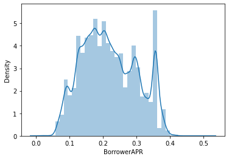

```python
# Since our major feature of interest is numeric, let plot the histogram distribution of the Borrower's APR
sb.distplot(df_loan_vis['BorrowerAPR'], bins = 40) # plotting with static bins
plt.show()
```

```python
df_loan_vis['BorrowerAPR'].describe()
```

```
count    113912.000000
mean          0.218828
std           0.080364
min           0.006530
25%           0.156290
50%           0.209760
75%           0.283810
max           0.512290
Name: BorrowerAPR, dtype: float64
```

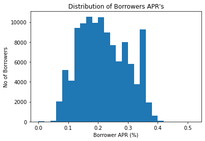

```python
bin_edges = np.arange(0, df_loan_vis['BorrowerAPR'].max() + 0.02, 0.02 ) # Plotting with dynamic bins
sb.distplot(df_loan_vis['BorrowerAPR'], bins = bin_edges, kde = False,
            hist_kws = {'alpha' : 1})
plt.xlabel('Borrower APR (%)')
plt.ylabel('No of Borrowers')
plt.title("Distribution of Borrowers APR's")
plt.show()
```

```python
df_loan_vis[df_loan_vis['BorrowerAPR'] > 0.42].shape[0] # we have just 7 borrowers greater than 0.43
```

```
7
```

The data shows that most of the loans has APR of less than 0.42.the distribution also looks multimodal as the we have peaks values at 0.1, 0.2, 0.3 and between 0.3 and 0.4

Next up, the first predictor variable of interest: LoanOriginalAmount

```python
df_loan_vis['LoanOriginalAmount'].describe()
```

```
count    113912.000000
mean       8338.015661
std        6245.940592
min        1000.000000
25%        4000.000000
50%        6500.000000
75%       12000.000000
max       35000.000000
Name: LoanOriginalAmount, dtype: float64
```

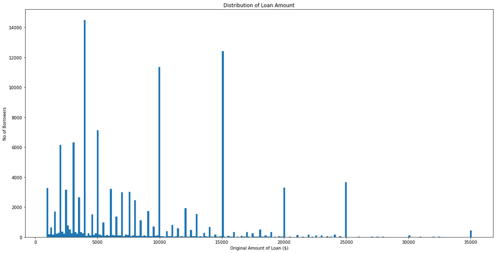

```python
# this data is also numeric, so let use the matplotlib function for plotting histograms
bins_edges = np.arange(900, df_loan_vis.LoanOriginalAmount.max()+150, 150)
plt.figure(figsize=[20, 10])
plt.hist(data = df_loan_vis, x = 'LoanOriginalAmount', bins = bins_edges);
plt.xlabel('Original Amount of Loan ($)')
plt.title('Distribution of Loan Amount')
plt.ylabel('No of Borrowers')
plt.show()
```

Now lets look at Employee duration on Job

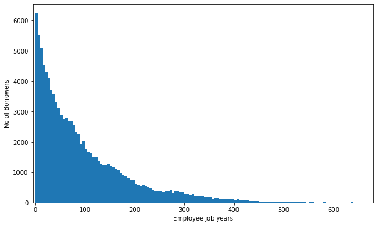

```python
bins = np.arange(0, df_loan_vis.EmploymentStatusDuration.max()+5, 5)
plt.figure(figsize=[10, 6])
plt.hist(data = df_loan_vis, x = 'EmploymentStatusDuration', bins = bins);
plt.xlabel('Employee job years')
plt.xlim([-5, 680])
plt.ylabel('No of Borrowers')
plt.show()
```

> This data seems to be right skewed as more employee as stayed on the job between 0 to 100 month and we have less employee that has stayed for more than 200 month

> Also, the number of people borrower seems to reduce with increase in years of employee on a job

```python
#let look at loan terms in years

df_loan_vis['Term_year'] = df_loan_vis['Term']/12
```

```python
# lets look at the monthly income
df_loan_vis['StatedMonthlyIncome'].describe()
```

```
count    1.139120e+05
mean     5.606973e+03
std      7.478338e+03
min      0.000000e+00
25%      3.200000e+03
50%      4.666667e+03
75%      6.817083e+03
max      1.750003e+06
Name: StatedMonthlyIncome, dtype: float64
```

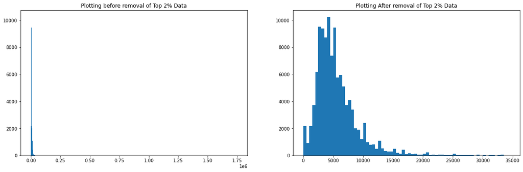

```python
plt.figure(figsize=[20, 6])
plt.subplot(1,2,1)
bins = np.arange(0, df_loan_vis['StatedMonthlyIncome'].max() + 500, 500)
plt.hist(data = df_loan_vis, x = 'StatedMonthlyIncome', bins = bins);
plt.title('Plotting before removal of Top 2% Data')
plt.subplot(1,2,2)
bins_edges = np.arange(0, 35000, 500)
plt.hist(data = df_loan_vis, x = 'StatedMonthlyIncome', bins = bins_edges)
plt.title('Plotting After removal of Top 2% Data')
plt.show()
```

> The histogram plot of the original data is rightly skewed and not clear to make any reasonable conclusion. so i used the summary statistics to estimate the max value which is 1.750003e+06 and this seems like an error. in the second plot I used 2% data and got a more reasonable plot

> From the second plot, the stated monthly is right skewed with most of the income less than 25k

```python
df_loan_vis['Term_year'].describe()
```

```
count    113912.000000
mean          3.402609
std           0.869759
min           1.000000
25%           3.000000
50%           3.000000
75%           3.000000
max           5.000000
Name: Term_year, dtype: float64
```

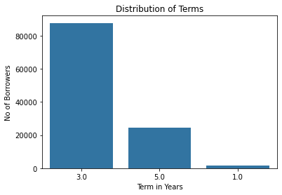

```python
base_color = sb.color_palette()[0]
term_order = df_loan_vis['Term_year'].value_counts().index
sb.countplot(data = df_loan_vis, x = 'Term_year', color = base_color, order = term_order)
plt.title('Distribution of Terms')
plt.xlabel('Term in Years')
plt.ylabel('No of Borrowers')
plt.show()
```

> We can see that people don’t really loan any amount for less than one year and the most popular loan amount is of 3 years followed by a 5 years period

```python
df_loan_vis[df_loan_vis['Term_year'] == 1]
```

|  | Occupation | LoanStatus | LoanOriginalAmount | BorrowerAPR | StatedMonthlyIncome | Term | ProsperRating (Alpha) | EmploymentStatus | IsBorrowerHomeowner | EmploymentStatusDuration | Term_year |
| --- | --- | --- | --- | --- | --- | --- | --- | --- | --- | --- | --- |
| 67 | Professional | Completed | 3000 | 0.35843 | 4777.000000 | 12 | E | Employed | False | 70.0 | 1.0 |
| 245 | Computer Programmer | Completed | 10000 | 0.11893 | 8333.333333 | 12 | A | Employed | False | 60.0 | 1.0 |
| 353 | Professional | Completed | 2000 | 0.28918 | 15000.000000 | 12 | D | Employed | True | 8.0 | 1.0 |
| 360 | Professional | Completed | 3000 | 0.34105 | 4333.333333 | 12 | D | Employed | True | 122.0 | 1.0 |
| 385 | Retail Management | Completed | 4000 | 0.31368 | 6666.666667 | 12 | E | Employed | False | 38.0 | 1.0 |
| ... | ... | ... | ... | ... | ... | ... | ... | ... | ... | ... | ... |
| 113776 | Computer Programmer | Completed | 3000 | 0.09986 | 23750.000000 | 12 | A | Employed | False | 69.0 | 1.0 |
| 113800 | Skilled Labor | Completed | 3370 | 0.22357 | 6250.000000 | 12 | C | Employed | False | 41.0 | 1.0 |
| 113829 | Executive | Completed | 5000 | 0.23554 | 15000.000000 | 12 | C | Employed | False | 12.0 | 1.0 |
| 113834 | Engineer - Mechanical | Completed | 2000 | 0.17969 | 7083.333333 | 12 | B | Employed | True | 231.0 | 1.0 |
| 113889 | Computer Programmer | Chargedoff | 4000 | 0.17969 | 8333.333333 | 12 | B | Employed | False | 8.0 | 1.0 |

1614 rows × 11 columns

```python
# let's convert Prosperity rating and employment status into ordered categorical variables
dict_loan_variable = {'ProsperRating (Alpha)': ['HR','E','D','C','B','A','AA'],
                    'EmploymentStatus': ['Employed','Self-employed','Full-time','Part-time','Retired','Other','Not employed', 'Not available']}

for var in dict_loan_variable:
    ordered_var = pd.api.types.CategoricalDtype(ordered = True,
                                                categories = dict_loan_variable[var])
    df_loan_vis[var] = df_loan_vis[var].astype(ordered_var)
```

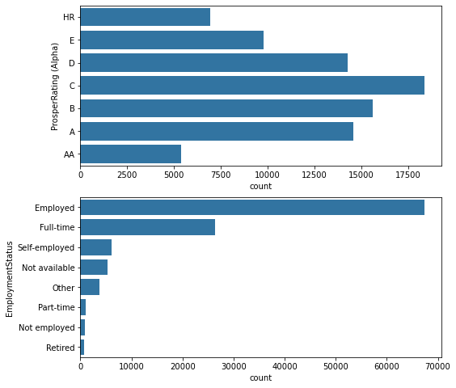

```python
#Lets Plot the distribution of the other categorical variables
fig, ax = plt.subplots(nrows=2, figsize = [8,8])

type_order = df_loan_vis.EmploymentStatus.value_counts().index

base_color = sb.color_palette()[0]
sb.countplot(data = df_loan_vis, y = 'ProsperRating (Alpha)', color = base_color,  ax = ax[0])
sb.countplot(data = df_loan_vis, y = 'EmploymentStatus', color = base_color,  order = type_order , ax = ax[1])

plt.show()
```

> For the visualization, we can see that most borrowers are employed and full time. Also, the ratings of most borrowers is C with AA been the lowest borrowers ratings

### Discuss the distribution(s) of your variable(s) of interest. Were there any unusual points? Did you need to perform any transformations?

> The Borrowers APR Look Multimodal as it categorised by more than one modes and i did not perform any transformation

### Of the features you investigated, were there any unusual distributions? Did you perform any operations on the data to tidy, adjust, or change the form of the data? If so, why did you do this?

> The distributions of stated monthly income is highly right screwed. Most stated monthly incomes are less than 25k, but some of them are incredibly high, like greater than 100k. Surprisingly, most of borrowers with greater than 100k monthly income only loan less than 5k dollars.

> for the monthly income analysis, i had to use 2% of the data to make a reasonable conclusion

## Bivariate Exploration

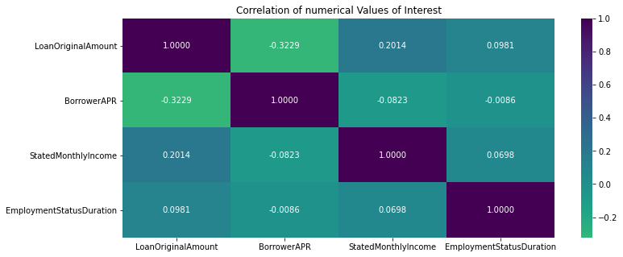

```python
# Since i have 4 numerical variable of interest, i will check the correlation of this variable using heatmaps

df_numeric_corr = df_loan_vis[['LoanOriginalAmount', 'BorrowerAPR', 'StatedMonthlyIncome', 'EmploymentStatusDuration']]

plt.figure(figsize = [12, 5])
sb.heatmap(df_numeric_corr.corr(), annot = True, fmt = '.4f',
           cmap = 'viridis_r', center = 0);
plt.title('Correlation of numerical Values of Interest')
```

> The Pearson correlation coefficient of borrower APR and loan original amount is -0.3229 which agrees with my prediction earlier, that is the more the loan amount, the lower the APR. The loan original amount is positively correlated with the stated monthly income which makes sense since borrowers with more monthly income can request to loan more money.loan original amount is also positively correlated with employstatus duration which also make sense since i expect that has stayed on job longer will have the higher propensity to pay back there loans

Let's Check how borrower APR, stated monthly income and loan original amount correlate with the categorical variables.

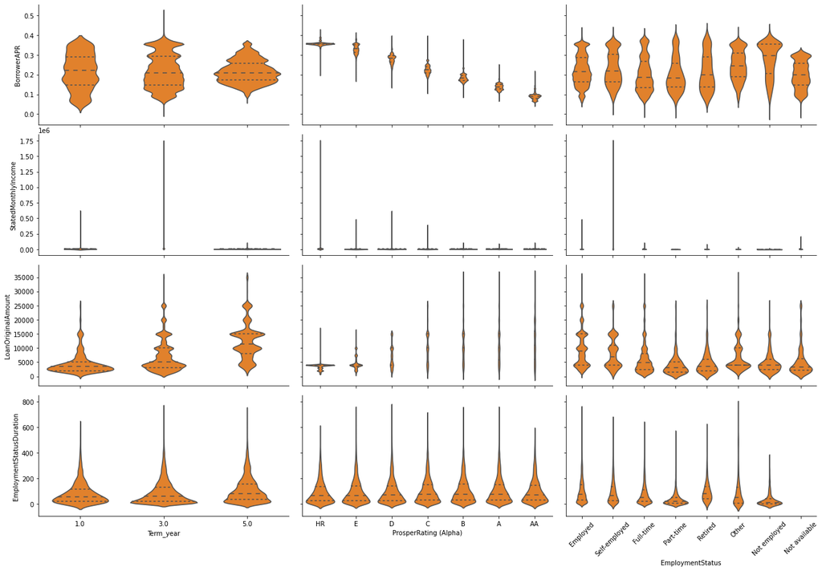

```python
def violin_plot(x, y, **kwargs):
    base_color = sb.color_palette()[1]
    sb.violinplot(x, y, color = base_color, inner = "quartile")

plt.figure(figsize = [12, 10])
g = sb.PairGrid(data = df_loan_vis, y_vars = ['BorrowerAPR', 'StatedMonthlyIncome', 'LoanOriginalAmount',
                                           'EmploymentStatusDuration'], x_vars =['Term_year', 'ProsperRating (Alpha)',
                                           'EmploymentStatus'] , size = 3, aspect = 2)
g.map(violin_plot);
plt.xticks(rotation=45);
plt.show()
```

> The plot above shows that the original loan amount increases as the loan term increases. Employed, self-employed and full time borrowers have more monthly income and loan amount than part-time, retired and not employed borrowers.The borrower APR decreases with the better rating. It means that the Prosper rating has a strong effect on borrower APR. Borrowers with better rating also have larger monthly income and loan amount. employee years on job does not effect on the other categorical here

Next, let look at the relationship between the term in years and other categorical variables, does people who get more time to pay back loan has monthly, proper rating and so on

```python
loan_counts = df_loan_vis.groupby(['ProsperRating (Alpha)', 'Term_year']).size()
loan_counts = loan_counts.reset_index(name='count')
loan_counts = loan_counts.pivot(index = 'ProsperRating (Alpha)', columns = 'Term_year', values = 'count')

loan_counts_two = df_loan_vis.groupby(['EmploymentStatus', 'Term_year']).size()
loan_counts_two = loan_counts_two.reset_index(name='count')
loan_counts_two = loan_counts_two.pivot(index = 'EmploymentStatus', columns = 'Term_year', values = 'count')

loan_counts_three = df_loan_vis.groupby(['EmploymentStatus', 'ProsperRating (Alpha)']).size()
loan_counts_three = loan_counts_three.reset_index(name='count')
loan_counts_three = loan_counts_three.pivot(index = 'EmploymentStatus', columns = 'ProsperRating (Alpha)', values = 'count')
```

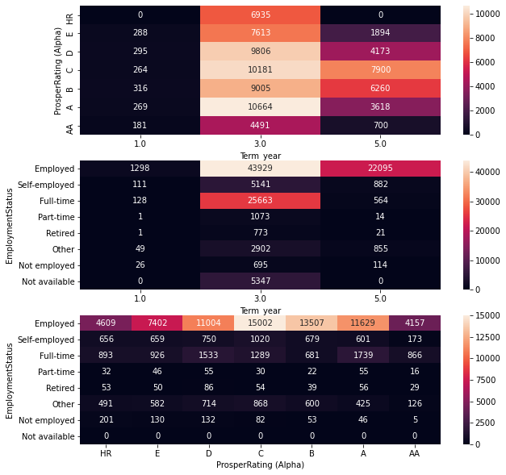

```python
plt.figure(figsize = [10, 10])

plt.subplot(3, 1, 1)
sb.heatmap(loan_counts, annot = True, fmt = 'd')

plt.subplot(3, 1, 2)

sb.heatmap(loan_counts_two, annot = True, fmt = 'd')

plt.subplot(3, 1, 3)
sb.heatmap(loan_counts_three, annot = True, fmt = 'd')
plt.show()
```

> For the first plot, we can see that there more 5 years loan on B and C ratings. Also we have the highest 3 years loans on A and C ratings. lastly there is only 3 years loan on HR Ratings

> For the third plot, employed received the highest C ratings

Now lets use scatter plot to see the relationship between the loan amount and the borrower APR. Althought will expect and negative correlation as depicted in the correlation of plot of the value -0.32

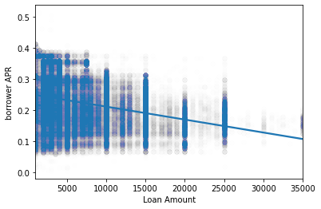

```python
# let use seaborn regplot to enable see the regression line

sb.regplot(data =  df_loan_vis, x = 'LoanOriginalAmount', y = 'BorrowerAPR', scatter_kws={'alpha':0.005})
plt.xlabel('Loan Amount')
plt.ylabel('borrower APR')
plt.show()
```

> The regression line above show a clearer relationship between the loan amount and borrowers APR. borrower APR reduces as the loan amount increases

### Talk about some of the relationships you observed in this part of the investigation. How did the feature(s) of interest vary with other features in the dataset?

> I observed that borrower APR has a negative correlation with the loan amount which mean the higher the loan amount, the lower the APR. I was able to confirm that people generally take loans more on a 3 years as deduce from the Univariate plots earlier. lastly, the Prosper rating also has a strong effect on the borrower APR, which decreases with the better rating.

### Did you observe any interesting relationships between the other features (not the main feature(s) of interest)?

> The loan original amount is positively correlated with the stated monthly income, it makes sense since borrowers with more monthly income can request to loan more money. It also shows that borrowers with better rating also have larger monthly income and loan amount. There is a interaction between prosper rating and term. Also, there are more 5 years loans on B and C ratings. There is only 3 years loans for HR rating borrowers.

## Multivariate Exploration

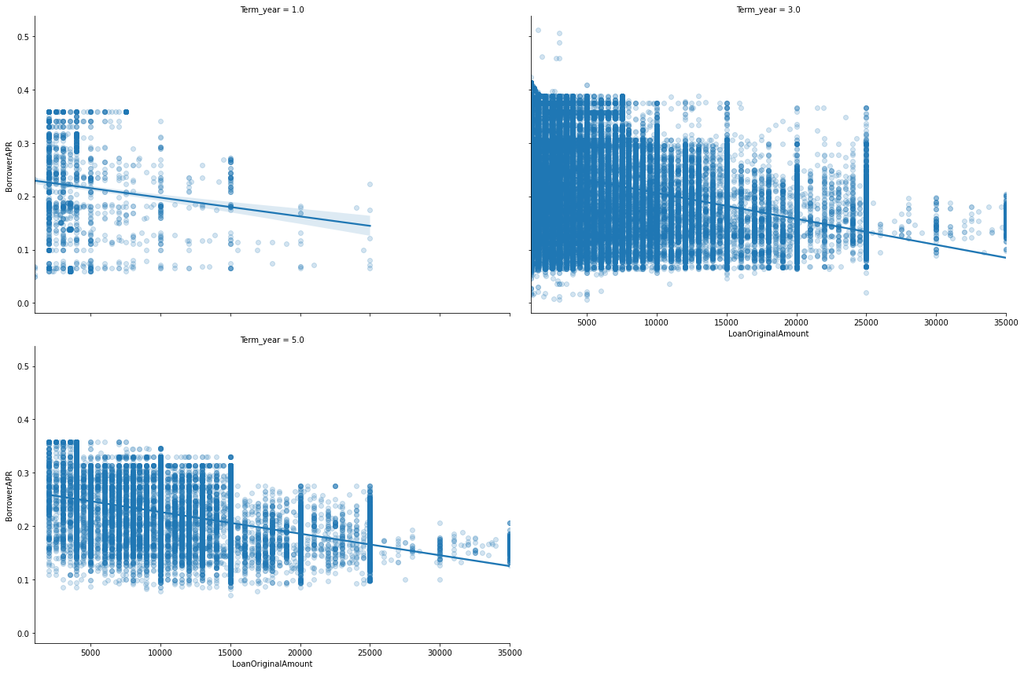

```python
# Term effect on Relationship of APR and loan amount
Term_in_years =sb.FacetGrid(data= df_loan_vis, aspect=1.5, height=6, col='Term_year', col_wrap=2)
Term_in_years.map(sb.regplot, 'LoanOriginalAmount', 'BorrowerAPR', x_jitter = 0.05, scatter_kws={'alpha':0.2});
Term_in_years.add_legend();
```

> Term has no visible effect on the relationship between loan and and borrowers APR

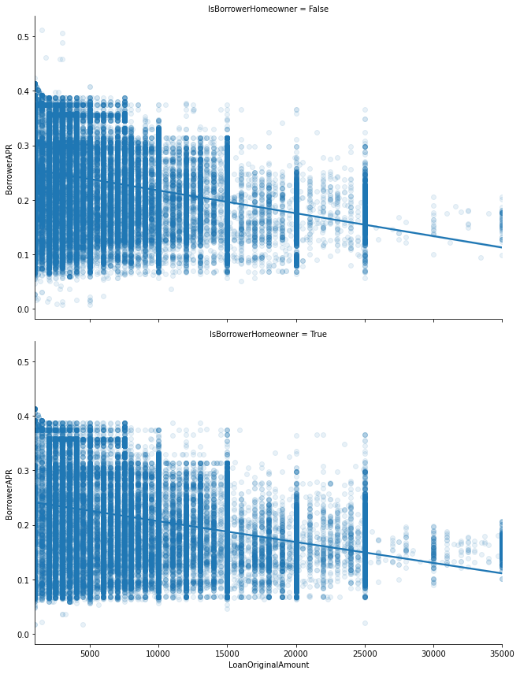

```python
# Homeower effect on relationship of APR and loan amount
plt.figure(figsize = [20, 10])
df_loan_vis['IsBorrowerHomeowner'] = df_loan_vis['IsBorrowerHomeowner'].astype('category')
Homeowner =sb.FacetGrid(data=df_loan_vis, aspect=1.5, height=6, col='IsBorrowerHomeowner', col_wrap=1)
Homeowner.map(sb.regplot, 'LoanOriginalAmount', 'BorrowerAPR', x_jitter=0.04, scatter_kws={'alpha':0.1});
Homeowner.add_legend()
plt.show();
```

> Having a mortgage on your credit profile has no visible effect on the relationship between loan and and borrowers APR

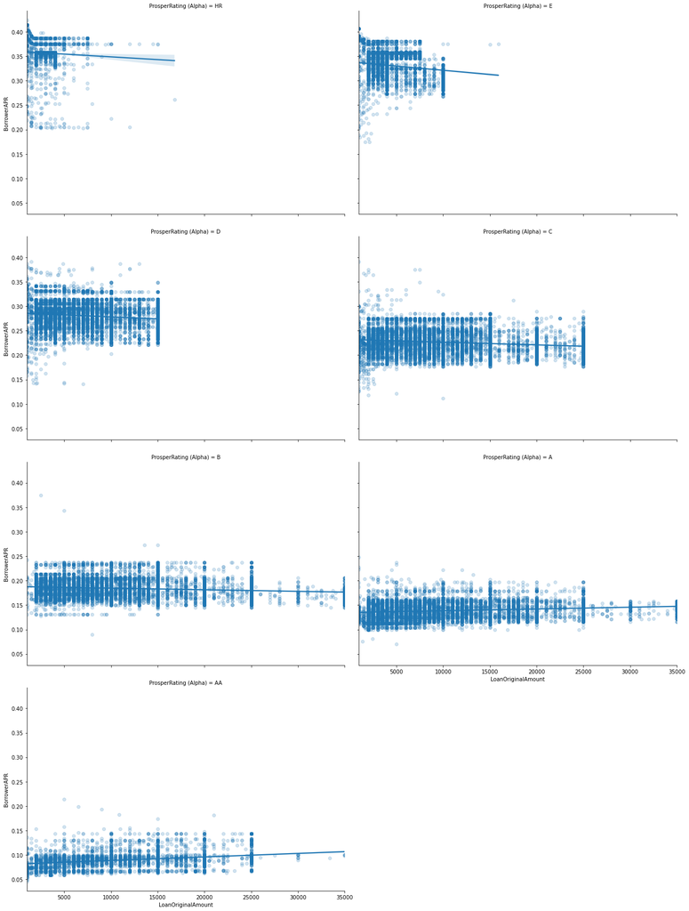

```python
plt.figure(figsize = [30, 10])
rating =sb.FacetGrid(data=df_loan_vis, aspect=1.5, height=6, col='ProsperRating (Alpha)', col_wrap=2)
rating.map(sb.regplot, 'LoanOriginalAmount', 'BorrowerAPR', x_jitter=0.05, scatter_kws={'alpha':0.2});
rating.add_legend()
plt.show();
```

> loan amount has a negative correlation with borrowers APR from the proper rating of HR to B ratings. However, the relationship turns slight positive for A and AA ratings

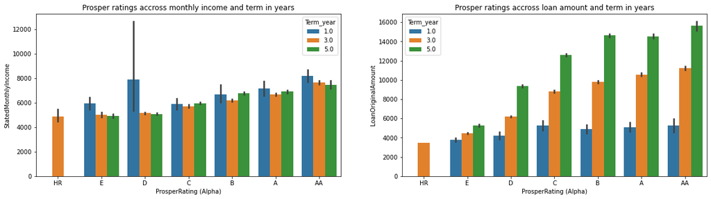

```python
plt.figure(figsize = [20, 5])
plt.subplot(1, 2, 1)
sb.barplot(data = df_loan_vis, x = 'ProsperRating (Alpha)', y = 'StatedMonthlyIncome', hue = 'Term_year')
plt.title('Prosper ratings accross monthly income and term in years')
plt.subplot(1, 2, 2)
sb.barplot(data = df_loan_vis, x = 'ProsperRating (Alpha)', y = 'LoanOriginalAmount', hue = 'Term_year')
plt.title('Prosper ratings accross loan amount and term in years')
plt.show()
```

Let's look at borrower APR at different rating across different terms

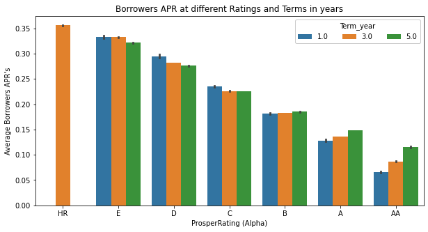

```python
fig = plt.figure(figsize = [10,5])
ax = sb.barplot(data = df_loan_vis, x = 'ProsperRating (Alpha)', y = 'BorrowerAPR', hue = 'Term_year')
ax.legend(loc = 1, ncol = 3, framealpha = 1, title = 'Term_year')
plt.title('Borrowers APR at different Ratings and Terms in years')
plt.ylabel("Average Borrowers APR's")
plt.show()
```

> From the visualization, we can see that borrower APR decrease with the increase of borrow term for people with HR-C prosper ratings. For people with B-AA ratings, the APR increase with the increase of borrower's term.

### Were there any interesting or surprising interactions between features?

> A surprising relationship is that the borrower APR and loan amount is negatively correlated when the Prosper ratings are from HR to B, but the correlation is turned to be positive when the ratings are A and AA. Another interesting thing is that the borrower APR decrease with the increase of borrow term for people with HR-C raings. But for people with B-AA ratings, the APR increase with the borrow term.